# A7 - Networks

Beixuan Jia

11/7/2020

```r
knitr::opts_chunk$set(fig.width=20, fig.height=16)
library(dplyr)
library(ggplot2)
library(scales)
options(scipen = 999)
```

```r
library(readxl)
state <- read_excel("State_to_State_Migrations_Table_2018.xls")
```

```
## * `` -> ...2
## * `` -> ...3
## * `` -> ...4
## * `` -> ...5
## * `` -> ...6
## * ...
```

##### Data Cleaning

Selected origin states: NY, TX, CA, MD

```r
state <- state[,c(1, 19, 54, 81, 105)]
state <- state[-c(1:5),]
names(state) <- as.matrix(state[1, ])
state <- state[-1, ]
state[] <- lapply(state, function(x) type.convert(as.character(x)))
state <- state[-c(1:4),]
state = state[complete.cases(state), ]
names(state) <- c("curr_states", "California", "Maryland", "New York", "Texas")
```

```r
state$California = as.numeric(as.character(state$California))
state$`New York` = as.numeric(as.character(state$`New York`))
state$Texas = as.numeric(as.character(state$Texas))
state$Maryland = as.numeric(as.character(state$Maryland))
```

##### Generate the top 10 destinations for the 4 states

```r
top_dest <- function(x) {
  rank <- state[order(-state[x]), ]
  rank <- rank[,c('curr_states', x)]
  rank$source <- x
  names(rank)[names(rank)=='curr_states'] <- 'target'
  names(rank)[names(rank)==x] <- 'count'
  rank = rank[,c(3,1,2)]
  head(rank, 10)
}

top_dest_NY <- top_dest("New York")
top_dest_TX <- top_dest("Texas")
top_dest_CA <- top_dest("California")
top_dest_MD <- top_dest("Maryland")
```

##### Define Edges

```r
edge <- do.call("rbind", list(top_dest_NY, top_dest_TX, top_dest_CA, top_dest_MD))
print(edge)
```

```
## # A tibble: 40 x 3
##    source   target         count
##    <chr>    <fct>          <dbl>
##  1 New York New Jersey     64810
##  2 New York Florida        63033
##  3 New York Pennsylvania   43048
##  4 New York California     34848
##  5 New York Connecticut    27361
##  6 New York North Carolina 25596
##  7 New York Massachusetts  19960
##  8 New York Texas          18925
##  9 New York Virginia       17983
## 10 New York South Carolina 12721
## # ... with 30 more rows
```

```r
library("varhandle")
edge$target <- unfactor(edge$target)
```

##### Define Nodes

```r
node1 <- unique(edge$target)
node2 <- unique(edge$source)
node <- c(node1, node2)
node <- unique(node)
```

```r
node = as.data.frame(node)
```

##### Define Graph

```r
library(igraph)
```

Graph Info

```r
routes_igraph <- graph_from_data_frame(d = edge, vertices = unique(node), directed = TRUE)
routes_igraph
```

```
## IGRAPH 67e5a49 DN-- 23 40 --
## + attr: name (v/c), count (e/n)
## + edges from 67e5a49 (vertex names):
##  [1] New York  ->New Jersey     New York  ->Florida
##  [3] New York  ->Pennsylvania   New York  ->California
##  [5] New York  ->Connecticut    New York  ->North Carolina
##  [7] New York  ->Massachusetts  New York  ->Texas
##  [9] New York  ->Virginia       New York  ->South Carolina
## [11] Texas     ->California     Texas     ->Oklahoma
## [13] Texas     ->Colorado       Texas     ->Florida
## [15] Texas     ->Louisiana      Texas     ->Georgia
## + ... omitted several edges
```

##### Plot the Graph

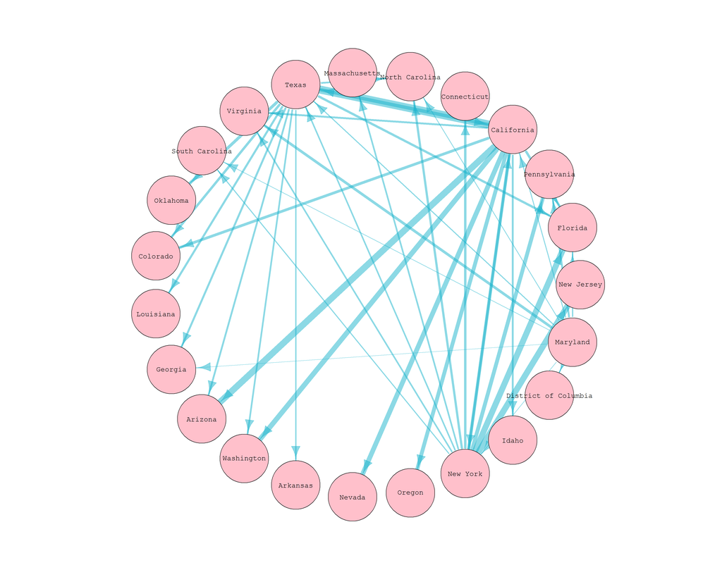

```r
# deg <- degree(routes_igraph, mode="all")
l <- layout_in_circle(routes_igraph)

plot(routes_igraph,
     layout=l,
     edge.arrow.size=2,
     edge.color=rgb(0.1,0.7,0.8,0.5),
     vertex.label.size=7,
     vertex.label.cex=1.2,
     vertex.label.font=10,
     vertex.shape="circle",
     vertex.color="pink",
     vertex.size=23,
     vertex.label.color="black",
     edge.width=(edge$count)/4000)
```

The network graph shows that some popular destinations of people from the 4 states (NY, TX, CA and MD) are FL, CA, TX, NC, and VA.

Other findings:

- Among all 4 states, people from CA migrated the most and people from MD moved the least in 2018.
- The Top 5 destinations for CA residents are TX, AZ, WA, NV, and OR
- The Top 5 destinations for TX residents are CA, OK, CO, FL, and LA
- The Top 5 destinations for NY residents are NJ, FL, PA, CA, and CT
- The Top 5 destinations for MD residents are VA, PA, FL, TX, and DC

This tells us people would generally moved to their adjacent states, with exceptions of big traveling states or states with a lot of job opportunities, such as FL, TX and CA. It’s also very interesting that CA and TX are each other’s top 1 destination.